# Surrogate Model Fitting for Membrane Stress: SVR, Polynomial Regression, and GPR

Converted from notebook · Week_5_Surrogate_model_fitting.ipynb

In this analysis we fit and compare three surrogate models—Support Vector Regression (SVR), Polynomial Regression, and Gaussian Process Regression (GPR)—to predict maximum membrane stress. We'll walk through model selection, training, evaluation, and how uncertainty is propagated from input variability into model predictions so you can interpret both performance and reliability.

|  | f_mem | sigma_mem | E_mem | nu_mem | sigma_edg | sigma_sup | sigma_mem_max |
| --- | --- | --- | --- | --- | --- | --- | --- |
| 0 | 0.268767 | 3220.880252 | 620830.965150 | 0.399472 | 325851.235578 | 322000.762345 | 4204.095289 |
| 1 | 0.511186 | 4603.969420 | 559505.773241 | 0.398297 | 266690.745363 | 366814.407254 | 5578.199692 |
| 2 | 0.316207 | 4020.464157 | 664063.602748 | 0.393333 | 350103.330214 | 308367.205040 | 4688.809620 |
| 3 | 0.457326 | 4282.802400 | 622714.404090 | 0.411230 | 313489.897816 | 327438.702828 | 5219.281260 |
| 4 | 0.261861 | 4097.033516 | 623600.545225 | 0.382459 | 334400.590712 | 474471.127871 | 4986.756515 |

```
Features shape: (200, 6)
Target shape: (200,)
Response name: sigma_mem_max
Feature names: ['f_mem', 'sigma_mem', 'E_mem', 'nu_mem', 'sigma_edg', 'sigma_sup']
```

# 1) SVR Model

Support Vector Regression (SVR) is a kernel-based method that fits a function within an epsilon-tube: small deviations are ignored while larger deviations are penalized. Here we standardize features and run a grid search over hyperparameters (C, epsilon, gamma) to find a parsimonious model that generalizes well. The printed `Best Parameters` correspond to the hyperparameters that produced the best cross-validated R², giving a reliable final model for predictions.

```
Best R2 Score: 0.9920780252709755
Best Parameters: {'svr__C': 1000, 'svr__epsilon': 0.001, 'svr__gamma': 0.01}
```

**What this means:** The cross-validated R² (~0.99) shows the SVR model explains most of the variance on held-out folds. The hyperparameters listed above are those selected by GridSearchCV and will be used in the final model to balance fit and generalization.

|  | R2_Train | R2_Test | MSE_Train | MSE_Test |
| --- | --- | --- | --- | --- |
| SVR | 0.996588 | 0.996911 | 713.568506 | 1138.151268 |

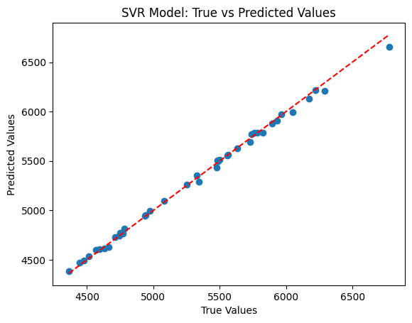

## 2) Polynomial Regression

Polynomial Regression augments the original features with polynomial terms, allowing a linear model to capture nonlinear relationships. We evaluate degrees 1 through 6 using 5-fold cross-validation and mean squared error (MSE) to select a degree that balances bias and variance—the printed MSEs show CV performance for each degree and the chosen best degree.

```
Degree 1: Mean 5-CV MSE = 3587.9366
Degree 2: Mean 5-CV MSE = 181.1121
Degree 3: Mean 5-CV MSE = 358.6103
Degree 4: Mean 5-CV MSE = 1208.5082
Degree 5: Mean 5-CV MSE = 1325.9332
Degree 6: Mean 5-CV MSE = 1482.9064

Best degree based on 5-CV MSE: 2

Training R²: 0.9995, MSE: 110.2521
Test R²: 0.9996, MSE: 137.5833
```

**Interpretation:** Degree 2 gives the lowest cross-validated MSE, indicating a quadratic expansion balances flexibility and generalization best. Very high R² on train/test implies accurate fit—verify this with residual plots to ensure no overfitting.

|  | R2_Train | R2_Test | MSE_Train | MSE_Test |
| --- | --- | --- | --- | --- |
| SVR | 0.996588 | 0.996911 | 713.568506 | 1138.151268 |
| PLY | 0.999473 | 0.999627 | 110.252095 | 137.583329 |

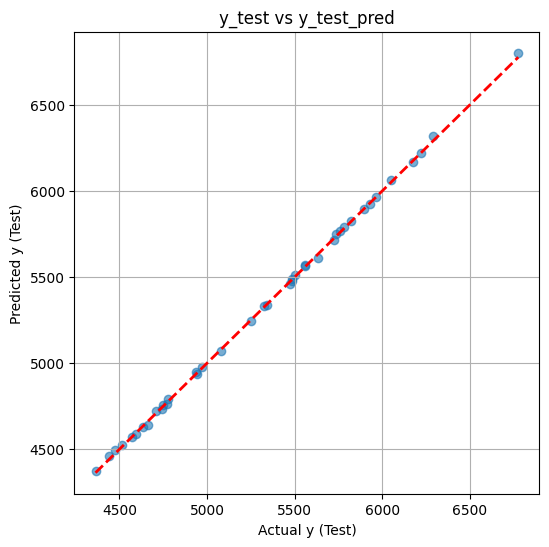

## 3) GPR

Gaussian Process Regression (GPR) is a probabilistic, non-parametric method that places a distribution over functions. Using an RBF kernel (scaled by a constant) and optimizing kernel hyperparameters gives both point predictions and an associated predictive standard deviation—this uncertainty is valuable when assessing confidence in individual predictions.

```
Gaussian Process Regression -> Training R²: 1.0000, MSE: 0.0000
Gaussian Process Regression -> Test R²: 0.9990, MSE: 364.3307
```

**Note:** GPR reports near-perfect training fit and excellent test performance; its key benefit beyond point estimates is the predictive standard deviation returned by `predict(..., return_std=True)`, which quantifies uncertainty and can show where predictions are less reliable.

|  | R2_Train | R2_Test | MSE_Train | MSE_Test |
| --- | --- | --- | --- | --- |
| SVR | 0.996588 | 0.996911 | 7.135685e+02 | 1138.151268 |
| PLY | 0.999473 | 0.999627 | 1.102521e+02 | 137.583329 |
| GPR | 1.000000 | 0.999011 | 6.232487e-11 | 364.330749 |

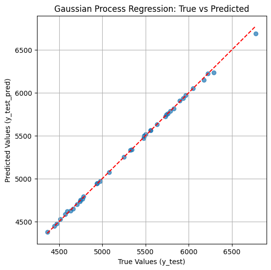

## 4) Uncertainty Propagation

To quantify output variability we perform Monte Carlo sampling from assumed input distributions (e.g., Gumbel for extreme loads, lognormal for material properties, uniform for uncertainty-bounded parameters). Each sample is passed through the surrogate models to build a predictive distribution—summary statistics and plots show the mean, spread, and coefficients of variation, which are useful for risk-aware decisions.

```
                      mean           std      variance
f_mem             0.400017      0.122363  1.497269e-02
sigma_mem_y   11006.915552   1647.463875  2.714137e+06
sigma_mem      4004.092529    800.288791  6.404621e+05
E_mem        599744.298013  91200.170008  8.317471e+09
sigma_edg    354031.078148  70842.419793  5.018648e+09
sigma_sup    400039.964252  81926.101818  6.711886e+09
nu_mem            0.400013      0.011426  1.305524e-04
```

```
/Users/anirudhparameswaran/Desktop/Case Studies - Computer Experiments/SVM/csenv/lib/python3.14/site-packages/sklearn/utils/validation.py:2749: UserWarning: X does not have valid feature names, but PolynomialFeatures was fitted with feature names
  warnings.warn(
```

```
array([5490.28901174, 5601.69053691, 4330.12129635, 6036.37014966,
       6903.1560084 , 4497.79035799, 5344.15778607, 4686.5053377 ,
       5965.08856618, 5568.03075001])
```

```
/Users/anirudhparameswaran/Desktop/Case Studies - Computer Experiments/SVM/csenv/lib/python3.14/site-packages/sklearn/utils/validation.py:2749: UserWarning: X does not have valid feature names, but StandardScaler was fitted with feature names
  warnings.warn(
```

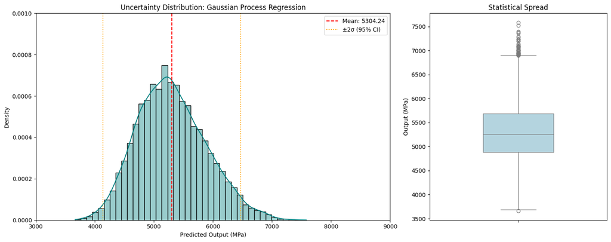

```
{'Mean': np.float64(5304.237185251169),
 'Std_Dev': np.float64(583.7463942883636),
 'COV_Percent': np.float64(11.005284528216695),
 'Min': np.float64(3664.0360457482307),
 'Max': np.float64(7579.685870666712)}
```

```
/Users/anirudhparameswaran/Desktop/Case Studies - Computer Experiments/SVM/csenv/lib/python3.14/site-packages/sklearn/utils/validation.py:2749: UserWarning: X does not have valid feature names, but PolynomialFeatures was fitted with feature names
  warnings.warn(
```

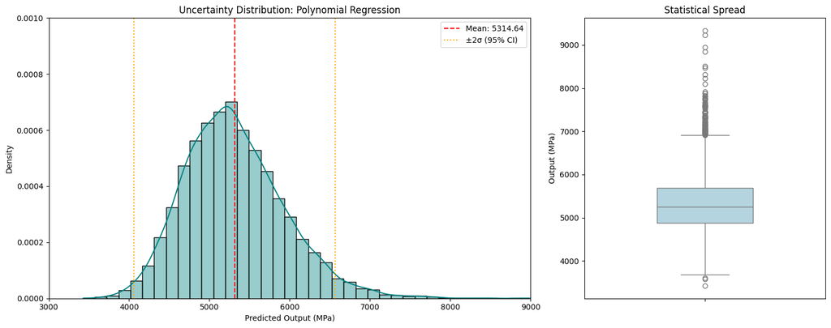

```
{'Mean': np.float64(5314.635055261468),
 'Std_Dev': np.float64(626.7527882294055),
 'COV_Percent': np.float64(11.79296003794132),
 'Min': np.float64(3427.106456259695),
 'Max': np.float64(9329.47237006467)}
```

```
/Users/anirudhparameswaran/Desktop/Case Studies - Computer Experiments/SVM/csenv/lib/python3.14/site-packages/sklearn/utils/validation.py:2749: UserWarning: X does not have valid feature names, but StandardScaler was fitted with feature names
  warnings.warn(
```

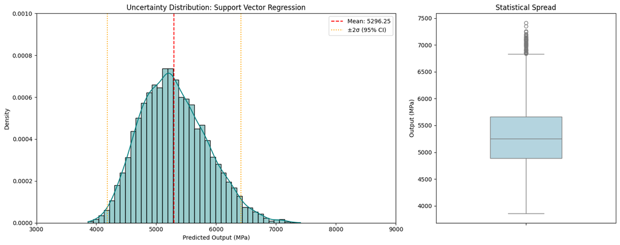

```
{'Mean': np.float64(5296.252812601258),
 'Std_Dev': np.float64(557.4042996804361),
 'COV_Percent': np.float64(10.524503255475576),
 'Min': np.float64(3860.85860081164),
 'Max': np.float64(7409.324511311017)}
```

**How to read this:** The Coefficient of Variation (≈10.5%) shows moderate relative variability in predicted stress—this is useful to compare uncertainty across different models or design scenarios.

## Conclusion

In summary, SVR—when carefully tuned—provides strong predictive performance, polynomial regression can capture moderate nonlinearities with degree selection guided by cross-validation, and GPR offers the extra advantage of predictive uncertainty estimates. Monte Carlo uncertainty propagation translates input variability into an interpretable output distribution; next steps could include model ensembling, calibration with more data, or targeted experiments where model uncertainty is highest.